# Assignment 3

Setting the Training and Testing Environment

```r
Strain_Data<-read.csv("qb.train.csv")
str(Strain_Data)
```

```
## 'data.frame':    8079 obs. of  10 variables:
##  $ row        : int  1 2 3 4 5 6 7 8 9 10 ...
##  $ body_score : num  127.4 50.2 44.8 44.1 40.7 ...
##  $ page       : Factor w/ 3921 levels "...Baby One More Time (album)",..: 732 680 2880 2610 1576 1611 3839 28 1413 2550 ...
##  $ answer     : Factor w/ 2006 levels "'Tis Pity She's a Whore",..: 312 312 312 1956 1956 1956 1956 23 23 23 ...
##  $ text       : Factor w/ 3683 levels ".In this work, Truth and Beauty are buried in the concluding \"Threnos\" section while Love and Constancy had d"| __truncated__,..: 694 694 694 3056 3056 3056 3056 3337 3337 3337 ...
##  $ category   : Factor w/ 1 level "Literature": 1 1 1 1 1 1 1 1 1 1 ...
##  $ tournaments: Factor w/ 76 levels "1999 ACF Nationals",..: 3 3 3 68 68 68 68 3 3 3 ...
##  $ answer_type: Factor w/ 9 levels "abs","anim","char",..: 9 5 5 7 5 5 7 9 9 9 ...
##  $ corr       : Factor w/ 2 levels "False","True": 2 1 1 1 1 1 2 2 1 1 ...
##  $ inlinks    : int  62 5 6 22 0 69 7 4 389 8 ...
```

```r
STest_Data<-read.csv("qb.test.csv")
str(STest_Data)
```

```
## 'data.frame':    887 obs. of  8 variables:
##  $ row        : int  31 32 33 88 91 139 140 141 142 188 ...
##  $ body_score : num  40 27.5 27 45.8 99.8 ...
##  $ page       : Factor w/ 712 levels "A Clockwork Orange",..: 146 590 106 8 581 123 53 136 520 68 ...
##  $ text       : Factor w/ 411 levels "\"The Secret Miracle\" details a writer's last days under a Nazi death sentence.\t\"The Form of the Sword\" tel"| __truncated__,..: 320 320 320 117 405 116 116 116 116 130 ...
##  $ category   : Factor w/ 1 level "Literature": 1 1 1 1 1 1 1 1 1 1 ...
##  $ tournaments: Factor w/ 58 levels "1999 ACF Nationals",..: 4 4 4 6 6 53 53 53 53 32 ...
##  $ answer_type: Factor w/ 9 levels "abs","anim","char",..: 9 9 9 9 9 5 5 3 7 7 ...
##  $ inlinks    : int  4 1 2 5 11 8 147 13 47 83 ...
```

Downloading the necessary packages

```r
library(e1071)
library(cwhmisc)
```

We will work the Page Column

```r
paren_match<-function(page,text) {
    start<-cpos(page,"(")
  end<-cpos(page,")")
  if(!is.na(start) && !is.na(end)) {
    take_string_inside_brackets<-substring(page,start+1,end-1)
    return(grepl(tolower(take_string_inside_brackets),tolower(text),fixed=TRUE))
  }else{
    return(FALSE)
  }
}
```

Understanding the above function 1. cpos function finds the 1st position in the string that you have provided. Here we have provided “(” and “)” characters. We need their position. It will return NA if it doesn’t find

2. if(!is.na(start) && !is.na(end)) { take_string_inside_brackets<-substring(page,start+1,end-1) What this above line does from the page column it will take a value(word) whose position is greater than start position by 1 and less than 1 by end position

3.the value that we get from the above code, we will take it and check if the same value(word) exists in text column. If yes then return TRUE Tolower means it will change the word and text to lower cases

Scaling the Train Data

As the variables obs_len, body_score and inlinks have high values we have to scale these variables

```r
Strain_Data$paren_match<-apply(Strain_Data,1,function(x){paren_match(x['page'],x['text'])})
Strain_Data$obs_len <- apply(Strain_Data, 1, function(x) {nchar(x['text'])})
Strain_Data$scale_len <- scale(Strain_Data$obs_len)
Strain_Data$scale_score <- scale(Strain_Data$body_score)
Strain_Data$log_links <- scale(log(as.numeric(Strain_Data$inlinks) + 1))
str(Strain_Data)
```

```
## 'data.frame':    8079 obs. of  15 variables:
##  $ row        : int  1 2 3 4 5 6 7 8 9 10 ...
##  $ body_score : num  127.4 50.2 44.8 44.1 40.7 ...
##  $ page       : Factor w/ 3921 levels "...Baby One More Time (album)",..: 732 680 2880 2610 1576 1611 3839 28 1413 2550 ...
##  $ answer     : Factor w/ 2006 levels "'Tis Pity She's a Whore",..: 312 312 312 1956 1956 1956 1956 23 23 23 ...
##  $ text       : Factor w/ 3683 levels ".In this work, Truth and Beauty are buried in the concluding \"Threnos\" section while Love and Constancy had d"| __truncated__,..: 694 694 694 3056 3056 3056 3056 3337 3337 3337 ...
##  $ category   : Factor w/ 1 level "Literature": 1 1 1 1 1 1 1 1 1 1 ...
##  $ tournaments: Factor w/ 76 levels "1999 ACF Nationals",..: 3 3 3 68 68 68 68 3 3 3 ...
##  $ answer_type: Factor w/ 9 levels "abs","anim","char",..: 9 5 5 7 5 5 7 9 9 9 ...
##  $ corr       : Factor w/ 2 levels "False","True": 2 1 1 1 1 1 2 2 1 1 ...
##  $ inlinks    : int  62 5 6 22 0 69 7 4 389 8 ...
##  $ paren_match: logi  TRUE FALSE FALSE FALSE FALSE FALSE ...
##  $ obs_len    : int  352 352 352 327 327 327 327 367 367 367 ...
##  $ scale_len  : num [1:8079, 1] -0.269 -0.269 -0.269 -0.385 -0.385 ...
##   ..- attr(*, "scaled:center")= num 410
##   ..- attr(*, "scaled:scale")= num 214
##  $ scale_score: num [1:8079, 1] 1.716 -0.212 -0.348 -0.366 -0.451 ...
##   ..- attr(*, "scaled:center")= num 58.7
##   ..- attr(*, "scaled:scale")= num 40
##  $ log_links  : num [1:8079, 1] 0.85 -0.615 -0.519 0.222 -1.732 ...
##   ..- attr(*, "scaled:center")= num 2.78
##   ..- attr(*, "scaled:scale")= num 1.6
```

```r
head(Strain_Data)
```

```
##   row body_score                page              answer
## 1   1  127.39804 Comus (John Milton) Comus (John Milton)
## 2   2   50.21234               Circe Comus (John Milton)
## 3   3   44.76707               Satyr Comus (John Milton)
## 4   4   44.05827      Philip K. Dick        Wilfred Owen
## 5   5   40.67525    Honore de Balzac        Wilfred Owen
## 6   6   40.43770       Hydra (genus)        Wilfred Owen
##                                                                                                                                                                                                                                                                                                          …
## 1 First performed in Ludlow Castle by the children of the earl of Bridgewater, it involves a young lady who is left in the woods by her two brothers who have gone to find food.\tTaken from the Greek for "revel," characters include the river nymph Sabrina and the god of sensual pleasure, the son o…
## 2 First performed in Ludlow Castle by the children of the earl of Bridgewater, it involves a young lady who is left in the woods by her two brothers who have gone to find food.\tTaken from the Greek for "revel," characters include the river nymph Sabrina and the god of sensual pleasure, the son o…
## 3 First performed in Ludlow Castle by the children of the earl of Bridgewater, it involves a young lady who is left in the woods by her two brothers who have gone to find food.\tTaken from the Greek for "revel," characters include the river nymph Sabrina and the god of sensual pleasure, the son o…
## 4                           This author is convinced by another to publish his work in The Hydra in Pat Barker's novel Regeneration.\tIn real life, this author claimed that "Neither should I go fooling over clouds / Following gleams unsafe, untrue" in one work, while the line "Whatever shares / T…
## 5                           This author is convinced by another to publish his work in The Hydra in Pat Barker's novel Regeneration.\tIn real life, this author claimed that "Neither should I go fooling over clouds / Following gleams unsafe, untrue" in one work, while the line "Whatever shares / T…
## 6                           This author is convinced by another to publish his work in The Hydra in Pat Barker's novel Regeneration.\tIn real life, this author claimed that "Neither should I go fooling over clouds / Following gleams unsafe, untrue" in one work, while the line "Whatever shares / T…
##     category        tournaments answer_type  corr inlinks paren_match
## 1 Literature 2000 ACF Nationals        work  True      62        TRUE
## 2 Literature 2000 ACF Nationals        None False       5       FALSE
## 3 Literature 2000 ACF Nationals        None False       6       FALSE
## 4 Literature    2009 ACF Winter      people False      22       FALSE
## 5 Literature    2009 ACF Winter        None False       0       FALSE
## 6 Literature    2009 ACF Winter        None False      69       FALSE
##   obs_len  scale_len scale_score  log_links
## 1     352 -0.2685592   1.7161399  0.8503135
## 2     352 -0.2685592  -0.2123920 -0.6149657
## 3     352 -0.2685592  -0.3484453 -0.5189054
## 4     327 -0.3851790  -0.3661550  0.2223939
## 5     327 -0.3851790  -0.4506820 -1.7315156
## 6     327 -0.3851790  -0.4566173  0.9159698
```

# GLM Model

Method 1 This accuracy is without spitting the data. The accuracy is considering the entire Train_data

```r
Sfunction<-function(Satul)
{
  model<-glm(corr~Satul,family = binomial(link='logit'),data = Strain_Data)
  Strain_Data$prediction <- predict(model,newdata=Strain_Data,type='response')
  Strain_Data$fitted.results <- ifelse(Strain_Data$prediction > 0.6,1,0)

  Strain_Data$corralter<-ifelse(Strain_Data$corr=="True",1,0)
  misClasificError <- mean(Strain_Data$fitted.results != Strain_Data$corralter)

  print(paste('Accuracy',1-misClasificError))
}
```

Once we created a function for accuracy. Let’s create a table having the parameters and their accuracy

```r
s<-c("body_score","scale_score","obs_len","obs_len+body_score","obs_len+paren_match","paren_match","scale_score+paren_match","scale_score+paren_match_scale_len","inlinks","log_links","scale_score+paren_match_scale_len+log_links")
h<-c(Sfunction(Strain_Data$body_score),Sfunction(Strain_Data$scale_score),Sfunction(Strain_Data$obs_len),Sfunction(Strain_Data$obs_len+Strain_Data$body_score),Sfunction(Strain_Data$obs_len+Strain_Data$paren_match),Sfunction(Strain_Data$paren_match),Sfunction(Strain_Data$scale_score+Strain_Data$paren_match),Sfunction(Strain_Data$scale_score+Strain_Data$paren_match+Strain_Data$scale_len),Sfunction(Strain_Data$inlinks),Sfunction(Strain_Data$log_links),Sfunction(Strain_Data$scale_len+Strain_Data$scale_score+Strain_Data$paren_match+Strain_Data$log_links))
```

```
## [1] "Accuracy 0.681767545488303"
## [1] "Accuracy 0.681767545488303"
## [1] "Accuracy 0.554276519371209"
## [1] "Accuracy 0.554400297066469"
## [1] "Accuracy 0.554276519371209"
## [1] "Accuracy 0.570120064364402"
## [1] "Accuracy 0.684861987869786"
## [1] "Accuracy 0.61554647852457"
```

```
## [1] "Accuracy 0.554276519371209"
## [1] "Accuracy 0.585468498576557"
## [1] "Accuracy 0.554276519371209"
```

Here is the code to create a table and putting the vector values created above

```r
Accuracy_tableLogistic <- data.frame(matrix(ncol = 2, nrow = 0))

i=1
N=11
for(i in 1:N){
  if(i < 12){
  d<-data.frame(s[i],h[i])
  Accuracy_tableLogistic<- rbind(Accuracy_tableLogistic,d)
  i+1

  }
}
colnames(Accuracy_tableLogistic)<-c("Parameters","Accuracy")
Accuracy_tableLogistic
```

```
##                                     Parameters                   Accuracy
## 1                                   body_score Accuracy 0.681767545488303
## 2                                  scale_score Accuracy 0.681767545488303
## 3                                      obs_len Accuracy 0.554276519371209
## 4                           obs_len+body_score Accuracy 0.554400297066469
## 5                          obs_len+paren_match Accuracy 0.554276519371209
## 6                                  paren_match Accuracy 0.570120064364402
## 7                      scale_score+paren_match Accuracy 0.684861987869786
## 8            scale_score+paren_match_scale_len  Accuracy 0.61554647852457
## 9                                      inlinks Accuracy 0.554276519371209
## 10                                   log_links Accuracy 0.585468498576557
## 11 scale_score+paren_match_scale_len+log_links Accuracy 0.554276519371209
```

By using the above method, we get the accuracies for all the above parameters given for the GLM model

Method 2 Here we are splitting the data and working on the trainset data of the Train_data

```r
index <- 1:nrow(Strain_Data)
testindex <- sample(index, trunc(length(index)/5))
testset <- Strain_Data[testindex,]
trainset <- Strain_Data[-testindex,]
```

Creating a similar function we created in the above steps

```r
Safunction<-function(Saatul)
{
  model1<-glm(corr~Saatul,family = binomial(link='logit'),data = trainset)
  trainset$prediction <- predict(model1,newdata=trainset,type='response')
  trainset$fitted.results <- ifelse(trainset$prediction > 0.6,1,0)

  trainset$corralter<-ifelse(trainset$corr=="True",1,0)
  misClasificError <- mean(trainset$fitted.results != trainset$corralter)

  print(paste('Accuracy',1-misClasificError))
}
```

```r
s<-c("body_score","scale_score","obs_len","obs_len+body_score","obs_len+paren_match","paren_match","scale_score+paren_match","scale_score+paren_match_scale_len","inlinks","log_links","scale_score+paren_match_scale_len+log_links")
a<-c(Safunction(trainset$body_score),Safunction(trainset$scale_score),Safunction(trainset$obs_len),Safunction(trainset$obs_len+trainset$body_score),Safunction(trainset$obs_len+trainset$paren_match),Safunction(trainset$paren_match),Safunction(trainset$scale_score+trainset$paren_match),Safunction(trainset$scale_score+trainset$paren_match+trainset$scale_len),Safunction(trainset$inlinks),Safunction(trainset$log_links),Safunction(trainset$scale_len+trainset$scale_score+trainset$paren_match+trainset$log_links))
```

```
## [1] "Accuracy 0.680383663366337"
## [1] "Accuracy 0.680383663366337"
## [1] "Accuracy 0.554455445544555"
## [1] "Accuracy 0.554455445544555"
## [1] "Accuracy 0.554455445544555"
## [1] "Accuracy 0.570235148514851"
## [1] "Accuracy 0.683941831683168"
## [1] "Accuracy 0.609839108910891"
```

```
## [1] "Accuracy 0.554455445544555"
## [1] "Accuracy 0.583539603960396"
## [1] "Accuracy 0.554455445544555"
```

```r
Accuracy_table_trainset <- data.frame(matrix(ncol = 2, nrow = 0))
i=1
N=11
for(i in 1:N){
  if(i < 12){
    l<-data.frame(s[i],a[i])
    Accuracy_table_trainset<- rbind(Accuracy_table_trainset,l)
    i+1
  }
}
colnames(Accuracy_table_trainset)<-c("Parameters","Accuracy")
Accuracy_table_trainset
```

```
##                                     Parameters                   Accuracy
## 1                                   body_score Accuracy 0.680383663366337
## 2                                  scale_score Accuracy 0.680383663366337
## 3                                      obs_len Accuracy 0.554455445544555
## 4                           obs_len+body_score Accuracy 0.554455445544555
## 5                          obs_len+paren_match Accuracy 0.554455445544555
## 6                                  paren_match Accuracy 0.570235148514851
## 7                      scale_score+paren_match Accuracy 0.683941831683168
## 8            scale_score+paren_match_scale_len Accuracy 0.609839108910891
## 9                                      inlinks Accuracy 0.554455445544555
## 10                                   log_links Accuracy 0.583539603960396
## 11 scale_score+paren_match_scale_len+log_links Accuracy 0.554455445544555
```

# Decision Tree

Creating a Function for Decision Tree

Note: We are working on the Trainset and Testset which belong to our original Train Data(STrain_data)

First let’s download all the necessary libraries requried

```r
library(rpart)
library(randomForest)
```

Function

```r
decision_tree <- function(dframe, name, dmodel, testset) {
  decision <- predict(dmodel,newdata= testset,type="class")
  Chandler<-ifelse(decision!="False","TRUE","FALSE")
  confusionMatrix<- table(Chandler, true=testset$corr)
  accuracy<-sum(diag(confusionMatrix)/sum(confusionMatrix))
  dframe <- rbind(dframe, data.frame(model=c(name), accuracy=c(accuracy)))
  return(dframe)
}
```

```r
results1<- data.frame(matrix(ncol = 2, nrow = 0))

results1 <- decision_tree(results1, "body_score", rpart(corr ~ body_score,method="class",data=trainset), testset)
results1 <- decision_tree(results1, "scale_score", rpart(corr ~ scale_score,method="class",data=trainset), testset)
results1 <- decision_tree(results1, "obs_len", rpart(corr ~ obs_len,method="class",data=trainset), testset)
results1 <- decision_tree(results1, "score+len", rpart(corr ~ obs_len + body_score,method="class", data=trainset), testset)
results1 <- decision_tree(results1, "paren+len", rpart(corr ~ obs_len + paren_match,method="class", data=trainset), testset)
results1 <- decision_tree(results1, "paren_match", rpart(corr ~ paren_match,method="class", data=trainset), testset)
results1 <- decision_tree(results1, "score+paren_match", rpart(corr ~ scale_score + paren_match,method="class", data=trainset), testset)
results1 <- decision_tree(results1, "score+len+paren_match", rpart(corr ~ scale_len + scale_score + paren_match,method="class", data=trainset), testset)
results1 <- decision_tree(results1, "links", rpart(corr ~ inlinks,method="class", data=trainset), testset)
results1 <- decision_tree(results1, "loglinks", rpart(corr ~ log_links,method="class", data=trainset), testset)
results1 <- decision_tree(results1, "score+len+links+paren_match", rpart(corr ~ scale_len + scale_score + log_links + paren_match,method="class", data=trainset), testset)
results1 <- decision_tree(results1, "score+links+paren_match", rpart(corr ~ scale_len + scale_score + paren_match,method="class", data=trainset), testset)
results1
```

```
##                          model  accuracy
## 1                   body_score 0.7609907
## 2                  scale_score 0.7609907
## 3                      obs_len 0.5535604
## 4                    score+len 0.7795666
## 5                    paren+len 0.5696594
## 6                  paren_match 0.5696594
## 7            score+paren_match 0.7609907
## 8        score+len+paren_match 0.7795666
## 9                        links 0.6266254
## 10                    loglinks 0.6266254
## 11 score+len+links+paren_match 0.7826625
## 12     score+links+paren_match 0.7795666
```

# SVM

1. Radial SVM

```r
SVM <- function(df, name, model, test) {
  svm.pred <- predict(model, test)
  svm.table <- table(pred = svm.pred, true=test$corr)
  df <- rbind(df, data.frame(model=c(name), score=c(classAgreement(svm.table)$diag)))
  return(df)
}
```

Get the most frequent baseline

```r
mfc_baseline <- sum(testset$corr == "False") / nrow(testset)
resultsSVM <- data.frame(model=c("MFC"), score=c(mfc_baseline))
```

```r
resultsSVM <- SVM(resultsSVM, "body_score", svm(corr ~ body_score, data=trainset), testset)
resultsSVM <- SVM(resultsSVM, "scale_score", svm(corr ~ scale_score, data=trainset), testset)
resultsSVM <- SVM(resultsSVM, "obs_len", svm(corr ~ obs_len, data=trainset), testset)
resultsSVM <- SVM(resultsSVM, "score+len", svm(corr ~ scale_len + obs_len, data=trainset), testset)
resultsSVM <- SVM(resultsSVM, "paren+obs_len", svm(corr ~ obs_len + paren_match, data=trainset), testset)
resultsSVM <- SVM(resultsSVM, "paren_match", svm(corr ~ paren_match, data=trainset), testset)
resultsSVM <- SVM(resultsSVM, "score+paren_match", svm(corr ~ scale_score + paren_match, data=trainset), testset)
resultsSVM <- SVM(resultsSVM, "score+len+paren_match", svm(corr ~ scale_len + scale_score + paren_match, data=trainset), testset)

resultsSVM <- SVM(resultsSVM, "loglinks", svm(corr ~ log_links, data=trainset), testset)
resultsSVM <- SVM(resultsSVM, "score+len+links+paren_match", svm(corr ~ scale_len + scale_score + log_links + paren_match, data=trainset), testset)
resultsSVM <- SVM(resultsSVM, "score+links+paren_match", svm(corr ~ scale_len + scale_score + paren_match, data=trainset), testset)
resultsSVM
```

```
##                          model     score
## 1                          MFC 0.5535604
## 2                   body_score 0.7628483
## 3                  scale_score 0.7628483
## 4                      obs_len 0.5535604
## 5                    score+len 0.5535604
## 6                paren+obs_len 0.5696594
## 7                  paren_match 0.5696594
## 8            score+paren_match 0.7684211
## 9        score+len+paren_match 0.8105263
## 10                    loglinks 0.6241486
## 11 score+len+links+paren_match 0.8061920
## 12     score+links+paren_match 0.8105263
```

2. Linear Kernel

```r
mfc_baseline <- sum(testset$corr == "False") / nrow(testset)
resultsSVMl <- data.frame(model=c("MFC"), score=c(mfc_baseline))
```

```r
resultsSVMl <- SVM(resultsSVMl, "body_score", svm(corr ~ body_score, data=trainset,kernel = 'linear'), testset)
resultsSVMl <- SVM(resultsSVMl, "scale_score", svm(corr ~ scale_score, data=trainset,kernel = 'linear'), testset)
resultsSVMl <- SVM(resultsSVMl, "obs_len", svm(corr ~ obs_len, data=trainset,kernel = 'linear'), testset)
resultsSVMl <- SVM(resultsSVMl, "score+len", svm(corr ~ obs_len + body_score, data=trainset,kernel = 'linear'), testset)
resultsSVMl <- SVM(resultsSVMl, "paren+len", svm(corr ~ obs_len + paren_match, data=trainset,kernel = 'linear'), testset)
resultsSVMl <- SVM(resultsSVMl, "paren_match", svm(corr ~ paren_match, data=trainset,kernel = 'linear'), testset)
resultsSVMl <- SVM(resultsSVMl, "score+paren_match", svm(corr ~ scale_score + paren_match, data=trainset,kernel = 'linear'), testset)
resultsSVMl <- SVM(resultsSVMl, "score+len+paren_match", svm(corr ~ scale_len + scale_score + paren_match, data=trainset,kernel = 'linear'), testset)

resultsSVMl <- SVM(resultsSVMl, "loglinks", svm(corr ~ log_links, data=trainset,kernel = 'linear'), testset)
resultsSVMl <- SVM(resultsSVMl, "score+len+links+paren_match", svm(corr ~ scale_len + scale_score + log_links + paren_match, data=trainset,kernel = 'linear'), testset)
resultsSVMl <- SVM(resultsSVMl, "score+links+paren_match", svm(corr ~ scale_len + scale_score + paren_match, data=trainset,kernel = 'linear'), testset)
resultsSVMl
```

```
##                          model     score
## 1                          MFC 0.5535604
## 2                   body_score 0.6990712
## 3                  scale_score 0.6990712
## 4                      obs_len 0.5535604
## 5                    score+len 0.7151703
## 6                    paren+len 0.5696594
## 7                  paren_match 0.5696594
## 8            score+paren_match 0.6996904
## 9        score+len+paren_match 0.7170279
## 10                    loglinks 0.6266254
## 11 score+len+links+paren_match 0.7318885
## 12     score+links+paren_match 0.7170279
```

3. Polynomial Kernel

```r
mfc_baseline <- sum(testset$corr == "False") / nrow(testset)
resultsSVMp <- data.frame(model=c("MFC"), score=c(mfc_baseline))
```

```r
resultsSVMp <- SVM(resultsSVMp, "body_score", svm(corr ~ body_score, data=trainset,kernel = 'polynomial'), testset)
resultsSVMp <- SVM(resultsSVMp, "scale_score", svm(corr ~ scale_score, data=trainset,kernel = 'polynomial'), testset)
resultsSVMp <- SVM(resultsSVMp, "obs_len", svm(corr ~ obs_len, data=trainset,kernel = 'polynomial'), testset)
resultsSVMp <- SVM(resultsSVMp, "score+len", svm(corr ~ obs_len + body_score, data=trainset,kernel = 'polynomial'), testset)
resultsSVMp <- SVM(resultsSVMp, "paren+len", svm(corr ~ obs_len + paren_match, data=trainset,kernel = 'polynomial'), testset)
resultsSVMp <- SVM(resultsSVMp, "paren_match", svm(corr ~ paren_match, data=trainset,kernel = 'polynomial'), testset)
resultsSVMp <- SVM(resultsSVMp, "score+paren_match", svm(corr ~ scale_score + paren_match, data=trainset,kernel = 'polynomial'), testset)
resultsSVMp <- SVM(resultsSVMp, "score+len+paren_match", svm(corr ~ scale_len + scale_score + paren_match, data=trainset,kernel = 'linear'), testset)

resultsSVMp <- SVM(resultsSVMp, "loglinks", svm(corr ~ log_links, data=trainset,kernel = 'polynomial'), testset)
resultsSVMp <- SVM(resultsSVMp, "score+len+links+paren_match", svm(corr ~ scale_len + scale_score + log_links + paren_match, data=trainset,kernel = 'polynomial'), testset)
resultsSVMp <- SVM(resultsSVMp, "score+links+paren_match", svm(corr ~ scale_len + scale_score + paren_match, data=trainset,kernel = 'polynomial'), testset)
resultsSVMp
```

```
##                          model     score
## 1                          MFC 0.5535604
## 2                   body_score 0.6489164
## 3                  scale_score 0.6489164
## 4                      obs_len 0.5535604
## 5                    score+len 0.6600619
## 6                    paren+len 0.5696594
## 7                  paren_match 0.5696594
## 8            score+paren_match 0.7721362
## 9        score+len+paren_match 0.7170279
## 10                    loglinks 0.5535604
## 11 score+len+links+paren_match 0.7907121
## 12     score+links+paren_match 0.7900929
```

4. Sigmoid Kernel

```r
mfc_baseline <- sum(testset$corr == "False") / nrow(testset)
resultsSVMs <- data.frame(model=c("MFC"), score=c(mfc_baseline))
```

```r
resultsSVMs <- SVM(resultsSVMs, "body_score", svm(corr ~ body_score, data=trainset,kernel = 'sigmoid'), testset)
resultsSVMs <- SVM(resultsSVMs, "scale_score", svm(corr ~ scale_score, data=trainset,kernel = 'sigmoid'), testset)
resultsSVMs <- SVM(resultsSVMs, "obs_len", svm(corr ~ obs_len, data=trainset,kernel = 'sigmoid'), testset)
resultsSVMs <- SVM(resultsSVMs, "score+len", svm(corr ~ obs_len + body_score, data=trainset,kernel = 'sigmoid'), testset)
resultsSVMs <- SVM(resultsSVMs, "paren+len", svm(corr ~ obs_len + paren_match, data=trainset,kernel = 'sigmoid'), testset)
resultsSVMs <- SVM(resultsSVMs, "paren_match", svm(corr ~ paren_match, data=trainset,kernel = 'sigmoid'), testset)
resultsSVMs <- SVM(resultsSVMs, "score+paren_match", svm(corr ~ scale_score + paren_match, data=trainset,kernel = 'sigmoid'), testset)
resultsSVMs <- SVM(resultsSVMs, "score+len+paren_match", svm(corr ~ scale_len + scale_score + paren_match, data=trainset,kernel = 'sigmoid'), testset)

resultsSVMs <- SVM(resultsSVMs, "loglinks", svm(corr ~ log_links, data=trainset,kernel = 'sigmoid'), testset)
resultsSVMs <- SVM(resultsSVMs, "score+len+links+paren_match", svm(corr ~ scale_len + scale_score + log_links + paren_match, data=trainset,kernel = 'sigmoid'), testset)
resultsSVMs <- SVM(resultsSVMs, "score+links+paren_match", svm(corr ~ scale_len + scale_score + paren_match, data=trainset,kernel = 'sigmoid'), testset)
resultsSVMs
```

```
##                          model     score
## 1                          MFC 0.5535604
## 2                   body_score 0.5232198
## 3                  scale_score 0.5232198
## 4                      obs_len 0.5009288
## 5                    score+len 0.5510836
## 6                    paren+len 0.5362229
## 7                  paren_match 0.5696594
## 8            score+paren_match 0.4594427
## 9        score+len+paren_match 0.4984520
## 10                    loglinks 0.5343653
## 11 score+len+links+paren_match 0.5517028
## 12     score+links+paren_match 0.4984520
```

# Question 2(b)

Error Analysis

We chose SVM kernel to be Radial as it gave best result. Parameter selected is scale_len+scale_score

Let’s create a confusion matrix

```r
SVMe <- predict(svm(corr ~ scale_len + scale_score, data=trainset),testset)
tab1 <- table(Predicted = SVMe, Actual = testset$corr)
tab1
```

```
##          Actual
## Predicted False True
##     False   855  257
##     True     39  464
```

Let’s create new variables for the type of the error and the prediction Type

```r
testsetdouble <- testset
SVM.new <-svm(corr ~ scale_len + scale_score, data=trainset)
SVM.new.p<- predict(SVM.new,testsetdouble)
testsetdouble$predval <- SVM.new.p
```

Creating new variables like errorType and predType

```r
for (i in 1:(nrow(testsetdouble)-1)) {
  if(testsetdouble$predval[i] == 'True' && testsetdouble$corr[i] == 'True')
  {
    testsetdouble$errorType[i] <- 'TP'
  }
  else if(testsetdouble$predval[i] == 'True' && testsetdouble$corr[i] == 'False')
  {
    testsetdouble$errorType[i] <- 'FP- Type I error'
  }
  else if(testsetdouble$predval[i] == 'False' && testsetdouble$corr[i] == 'True')
  {
    testsetdouble$errorType[i] <- 'FN - Type II error'
  }
  else
  {
    testsetdouble$errorType[i] <- 'TN'
  }
}


for (i in 1:(nrow(testsetdouble)-1)) {
  if(testsetdouble$errorType[i] == 'TP' || testsetdouble$errorType[i] == 'TN')
  {
    testsetdouble$predType[i] <- 'Correct Prediction'
  }
  else
  {
    testsetdouble$predType[i] <- 'Wrong Prediction'
  }

}
```

Let’s find the number of times FN-TYPE two error and FP-TYPE one error occurs for SVM

```r
Typeoneerror<-testsetdouble[(testsetdouble$errorType=="FP- Type I error"),]

Typetwoerror<-testsetdouble[(testsetdouble$errorType=="FN - Type II error"),]
```

# Second Method is Decision Tree

```r
Decisione <- predict(rpart(corr ~ scale_len + scale_score + log_links + paren_match, method = 'class', data=trainset),testset, type = 'class')
tab2 <- table(Predicted = Decisione, Actual = testset$corr)
tab2
```

```
##          Actual
## Predicted False True
##     False   866  323
##     True     28  398
```

```r
new.testset.decision <- testset
new.decision <-rpart(corr ~ scale_len + scale_score + log_links + paren_match, method = 'class', data=trainset)
new.p.decision <- predict(new.decision,new.testset.decision, type = 'class')
new.testset.decision$predval <- new.p.decision
```

Creating new variables like errorType and predType for this model

```r
for (i in 1:(nrow(new.testset.decision)-1)) {
  if(new.testset.decision$predval[i] == 'True' && new.testset.decision$corr[i] == 'True')
  {
    new.testset.decision$errorType[i] <- 'TP'
  }
  else if(new.testset.decision$predval[i] == 'True' && new.testset.decision$corr[i] == 'False')
  {
    new.testset.decision$errorType[i] <- 'FP- Type I error'
  }
  else if(new.testset.decision$predval[i] == 'False' && new.testset.decision$corr[i] == 'True')
  {
    new.testset.decision$errorType[i] <- 'FN - Type II error'
  }
  else
  {
    new.testset.decision$errorType[i] <- 'TN'
  }
}

for (i in 1:(nrow(new.testset.decision)-1)) {
  if(new.testset.decision$errorType[i] == 'TP' || new.testset.decision$errorType[i] == 'TN')
  {
    new.testset.decision$predType[i] <- 'Correct Prediction'
  }
  else
  {
    new.testset.decision$predType[i] <- 'Wrong Prediction'
  }

}
```

Let’s find the number of times FN-TYPE two error and FP-TYPE one error occurs for Decision Tree

```r
Typeoneerrordecision<-new.testset.decision[(new.testset.decision$errorType=="FP- Type I error"),]

Typetwoerrordecision<-new.testset.decision[(new.testset.decision$errorType=="FN - Type II error"),]
```

# Third Method: Logistic Regression

Confusion Matrix for Logistic Regression

```r
new.testset.logistic<- (predict(glm(corr ~scale_score+ paren_match, family = binomial(link = 'logit'), data=trainset),testset, type = 'response'))>0.6
tab3 <- table(Predicted = new.testset.logistic, Actual = testset$corr)
tab3
```

```
##          Actual
## Predicted False True
##     FALSE   880  495
##     TRUE     14  226
```

```r
new.testset.logistic1<- testset
new.lm <-glm(corr ~ scale_score + paren_match, family = binomial(link = 'logit'), data=trainset)
new.p.lm <- (predict(new.lm,new.testset.logistic1,type = 'response'))>0.6
new.testset.logistic1$predval <- new.p.lm
```

```r
for (i in 1:(nrow(new.testset.logistic1)-1)) {
  if(new.testset.logistic1$predval[i] == 'TRUE' && new.testset.logistic1$corr[i] == 'True')
  {
    new.testset.logistic1$errorType[i] <- 'TP'
  }
  else if(new.testset.logistic1$predval[i] == 'TRUE' && new.testset.logistic1$corr[i] == 'False')
  {
    new.testset.logistic1$errorType[i] <- 'FP- Type I error'
  }
  else if(new.testset.logistic1$predval[i] == 'FALSE' && new.testset.logistic1$corr[i] == 'True')
  {
    new.testset.logistic1$errorType[i] <- 'FN - Type II error'
  }
  else
  {
    new.testset.logistic1$errorType[i] <- 'TN'
  }
}


for (i in 1:(nrow(new.testset.logistic1)-1)) {
  if(new.testset.logistic1$errorType[i] == 'TP' || new.testset.logistic1$errorType[i] == 'TN')
  {
    new.testset.logistic1$predType[i] <- 'Correct Prediction'
  }
  else
  {
    new.testset.logistic1$predType[i] <- 'Wrong Prediction'
  }

}
```

Let’s find the number of times FN-TYPE two error and FP-TYPE one error occurs for Logistic

```r
Typeoneerrorlogistic<-new.testset.logistic1[(new.testset.logistic1$errorType=="FP- Type I error"),]

Typetwoerrorlogistic<-new.testset.logistic1[(new.testset.logistic1$errorType=="FN - Type II error"),]
```

Combining Error Type

SVM has least Type II error as compared to all other classifiers

Let’s install the necessary libraries to plot this

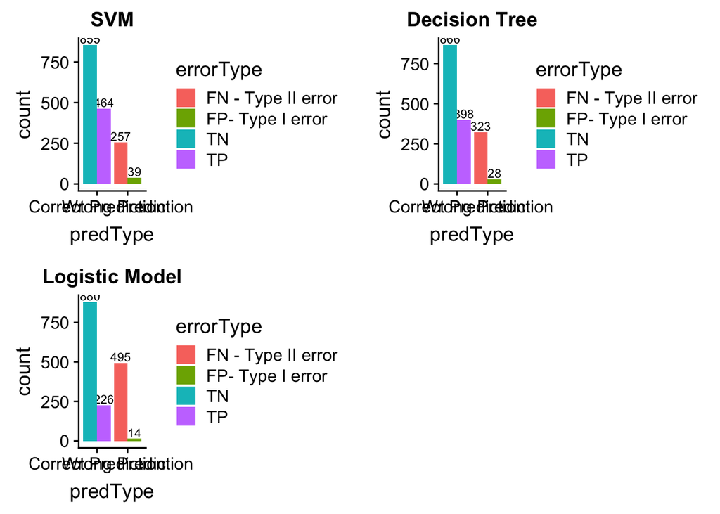

```r
library("ggplot2")
library("rpart.plot")
library("cowplot")
svm <-ggplot(data= testsetdouble, aes(x=predType, fill=errorType))+ geom_text(aes(label=..count..),stat= 'count',position = position_dodge(0.9),color = 'black',vjust=-0.2, size = 3)+geom_bar(position = 'dodge')+ ggtitle('SVM')

decision <- ggplot(data= new.testset.decision, aes(x=predType, fill=errorType))+geom_text(aes(label=..count..),stat= 'count',position = position_dodge(0.9),color = 'black',vjust=-0.2, size = 3)+geom_bar(position = 'dodge')+ggtitle('Decision Tree')

logistic <- ggplot(data= new.testset.logistic1, aes(x=predType, fill=errorType))+geom_text(aes(label=..count..),stat= 'count',position = position_dodge(0.9),color = 'black',vjust=-0.2, size = 3)+geom_bar(position = 'dodge')+ggtitle('Logistic Model')

plot_grid(svm,decision,logistic)
```

By looking at the above pattern

1. Type II error for SVM is less as compared to other classifiers
2. Total error for SVM is less as compared to others
3. All three classifiers give maximum accuracy for different parameters. But it is seen that scale_score is common between all three classifiers

Question 3:

3(a)

Improving Predictions

Ways to Improve the classifier:

1. SVM and Decision Tree give almost same result but decision tree is more reliable and its performance can be enhanced using ensemble methods, where many trees are fit and predictions are aggregated accross trees.

2.Amongst these ensemble methods, we choose Random Forest for improving the predictions

Random Forest is chosen as a classifier to improve the prediction because:

Random Forest produces large number of decision trees. This approach first takes a random sample of data and identifies a key set of features to grow each decision tree. These decision trees then have their OUt of Bag error determined. Then collection of decision trees are compared to find joint set of variables that creates strongest classification model.

Creating a function for Random forest

```r
randomf <- function(dframe, name, dmodel, testset) {
  decision <- predict(dmodel,newdata= testset,type="class")
  Chandler<-ifelse(decision!="False","TRUE","FALSE")
  confusionMatrix<- table(Chandler, true=testset$corr)
  accuracy<-sum(diag(confusionMatrix)/sum(confusionMatrix))
  dframe <- rbind(dframe, data.frame(model=c(name), accuracy=c(accuracy)))
  return(dframe)
}
```

```r
results12<- data.frame(matrix(ncol = 2, nrow = 0))

results12 <- randomf(results12, "body_score", randomForest(corr ~ body_score,data=trainset,proximty=TRUE), testset)
results12 <- randomf(results12, "scale_score", randomForest(corr ~ scale_score,method="class",data=trainset,proximty=TRUE), testset)
results12 <- randomf(results12, "obs_len", randomForest(corr ~ obs_len,data=trainset,proximty=TRUE), testset)
results12 <- randomf(results12, "score+len", randomForest(corr ~ obs_len + body_score, data=trainset,proximty=TRUE), testset)
results12 <- randomf(results12, "paren+len", randomForest(corr ~ obs_len + paren_match, data=trainset,proximty=TRUE), testset)
results12 <- randomf(results12, "paren_match", randomForest(corr ~ paren_match, data=trainset,proximty=TRUE), testset)
results12 <- randomf(results12, "score+paren_match", randomForest(corr ~ scale_score + paren_match, data=trainset,proximty=TRUE), testset)
results12 <- randomf(results12, "score+len+paren_match", randomForest(corr ~ scale_len + scale_score + paren_match, data=trainset,proximty=TRUE), testset)

results12 <- randomf(results12, "loglinks", randomForest(corr ~ log_links, data=trainset,proximty=TRUE), testset)
results12 <- randomf(results12, "score+len+links+paren_match", randomForest(corr ~ scale_len + scale_score + log_links + paren_match, data=trainset,proximty=TRUE), testset)
results12 <- randomf(results12, "score+links+paren_match", randomForest(corr ~ scale_len + scale_score + paren_match, data=trainset,proximty=TRUE), testset)
results12
```

```
##                          model  accuracy
## 1                   body_score 0.6712074
## 2                  scale_score 0.6712074
## 3                      obs_len 0.4947368
## 4                    score+len 0.8099071
## 5                    paren+len 0.5696594
## 6                  paren_match 0.5696594
## 7            score+paren_match 0.7609907
## 8        score+len+paren_match 0.7696594
## 9                     loglinks 0.6414861
## 10 score+len+links+paren_match 0.8253870
## 11     score+links+paren_match 0.7671827
```

Let’s understand this model

```r
model1<-randomForest(corr~scale_len + scale_score + log_links + paren_match,data=trainset,proximty=TRUE)
model1
```

```
##
## Call:
##  randomForest(formula = corr ~ scale_len + scale_score + log_links +      paren_match, data = trainset, proximty = TRUE)
##                Type of random forest: classification
##                      Number of trees: 500
## No. of variables tried at each split: 2
##
##         OOB estimate of  error rate: 19.04%
## Confusion matrix:
##       False True class.error
## False  3195  389   0.1085379
## True    842 2038   0.2923611
```

We are checking the number of trees used are sufficient

```r
oob.error.data <- data.frame(
  Trees=rep(1:nrow(model1$err.rate), times=3),
  Type=rep(c("OOB", "False", "True"), each=nrow(model1$err.rate)),
  Error=c(model1$err.rate[,"OOB"],
          model1$err.rate[,"False"],
          model1$err.rate[,"True"]))
```

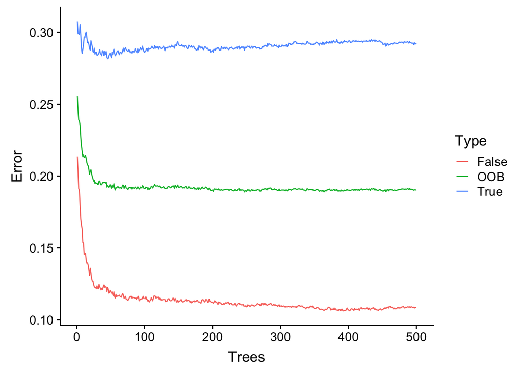

```r
library(ggplot2)
ggplot(data=oob.error.data, aes(x=Trees, y=Error)) + geom_line(aes(color=Type))
```

What will happen if we increase the number of trees?

```r
model1<-randomForest(corr~scale_len + scale_score + log_links + paren_match,data=trainset,ntree=1000,proximty=TRUE)
model1
```

```
##
## Call:
##  randomForest(formula = corr ~ scale_len + scale_score + log_links +      paren_match, data = trainset, ntree = 1000, proximty = TRUE)
##                Type of random forest: classification
##                      Number of trees: 1000
## No. of variables tried at each split: 2
##
##         OOB estimate of  error rate: 19.01%
## Confusion matrix:
##       False True class.error
## False  3192  392    0.109375
## True    837 2043    0.290625
```

```r
oob.error.data <- data.frame(
  Trees=rep(1:nrow(model1$err.rate), times=3),
  Type=rep(c("OOB", "False", "True"), each=nrow(model1$err.rate)),
  Error=c(model1$err.rate[,"OOB"],
          model1$err.rate[,"False"],
          model1$err.rate[,"True"]))
```

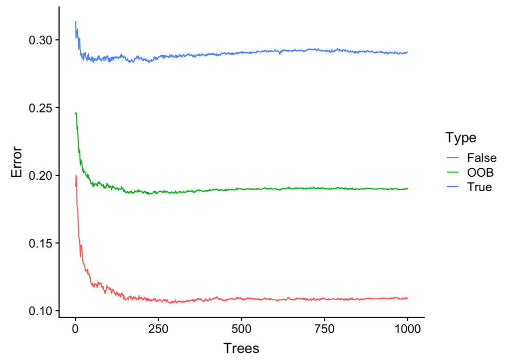

```r
library(ggplot2)
ggplot(data=oob.error.data, aes(x=Trees, y=Error)) + geom_line(aes(color=Type))
```

This doesn’t help. Let’s keep it at 500

Finding the parameter in Random Forest model with maximum accuracy

```r
results12[which.max(results12$accuracy),]
```

```
##                          model accuracy
## 10 score+len+links+paren_match 0.825387
```

As we see that the random forest gives the highest accuracy among all models So in question 4 to provide the score on Kaggle we have used Random Forest model

Error Analysis for Random Forest The parameters selected is score+len+links+paren_match Let’s Create a confusion Matrix

```r
e.p4 <- predict(randomForest(corr ~ scale_len + scale_score + log_links + paren_match, method = 'class', data= trainset),testset, type = 'class')
tab4 <- table(Predicted = e.p4, Actual = testset$corr)
tab4
```

```
##          Actual
## Predicted False True
##     False   809  198
##     True     85  523
```

```r
new.testset.random <- testset
new.random <-randomForest(corr ~ scale_len + scale_score + log_links + paren_match, method = 'class', data= trainset,proximity=T)
new.p.random <- predict(new.random,new.testset.random)
new.testset.random$predval <- new.p.random
```

```r
for (i in 1:(nrow(new.testset.random)-1)) {
  if(new.testset.random$predval[i] == 'True' && new.testset.random$corr[i] == 'True')
  {
    new.testset.random$errorType[i] <- 'TP'
  }
  else if(new.testset.random$predval[i] == 'True' && new.testset.random$corr[i] == 'False')
  {
    new.testset.random$errorType[i] <- 'FP- Type I error'
  }
  else if(new.testset.random$predval[i] == 'False' && new.testset.random$corr[i] == 'True')
  {
    new.testset.random$errorType[i] <- 'FN - Type II error'
  }
  else
  {
    new.testset.random$errorType[i] <- 'TN'
  }
}

for (i in 1:(nrow(new.testset.random)-1)) {
  if(new.testset.random$errorType[i] == 'TP' || new.testset.random$errorType[i] == 'TN')
  {
    new.testset.random$predType[i] <- 'Correct Prediction'
  }
  else
  {
    new.testset.random$predType[i] <- 'Wrong Prediction'
  }

}
```

The number of TYPE TWO Error

```r
ssrandomtype2<-new.testset.random[(new.testset.random$errorType=="FN - Type II error"),]
```

The number of TYPE ONE Error

```r
ssrandomtype1<-new.testset.random[(new.testset.random$errorType=="FP- Type I error"),]
```

Combining Error Type

We see that in Random Forest classifier the Type II error has decreased and the Type _I error has increased. The total error of SVM is near to the total error of Random forest Also, Type II error is more critical as ompared to Type I error which is decreased by using Random forest Classifier

Let’s plot this

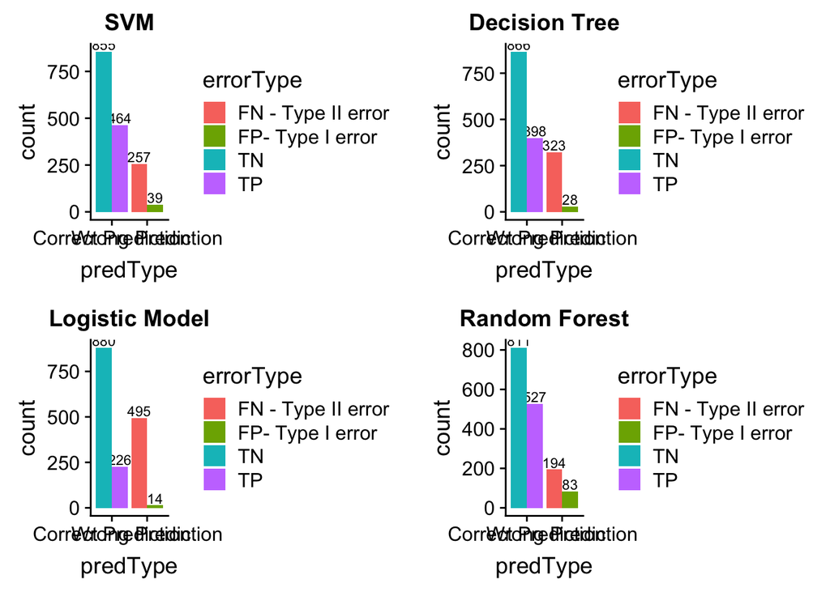

```r
svm1 <-ggplot(data= testsetdouble, aes(x=predType, fill=errorType))+ geom_text(aes(label=..count..),stat= 'count',position = position_dodge(0.9),color = 'black',vjust=-0.2, size = 3)+geom_bar(position = 'dodge')+ ggtitle('SVM')

decision1 <- ggplot(data= new.testset.decision, aes(x=predType, fill=errorType))+geom_text(aes(label=..count..),stat= 'count',position = position_dodge(0.9),color = 'black',vjust=-0.2, size = 3)+geom_bar(position = 'dodge')+ggtitle('Decision Tree')

logistic1 <- ggplot(data= new.testset.logistic1, aes(x=predType, fill=errorType))+geom_text(aes(label=..count..),stat= 'count',position = position_dodge(0.9),color = 'black',vjust=-0.2, size = 3)+geom_bar(position = 'dodge')+ggtitle('Logistic Model')

random1 <- ggplot(data= new.testset.random, aes(x=predType, fill=errorType))+geom_text(aes(label=..count..),stat= 'count',position = position_dodge(0.9),color = 'black',vjust=-0.2, size = 3)+geom_bar(position = 'dodge')+ggtitle('Random Forest')


plot_grid(svm1,decision1,logistic1,random1)
```

It can be seen that Random Forest not only decreases the type two error but also the TRUE positives have increased

# Question 3(b)

How much does the feature improve the classifier

We see that by using Random Forest 1. The accuracy is the highest compared to the other models 2. The Type Two error is the lowest. The overall error match with the overall error of SVM.so they both will have the lowest wrong predictions The True Positives of this model are the highest compared to other models

# Question 4(a)

4(a) Final score and Username

Final Score = 0.78571 Username = sanvekar and Display name = Sagar

Method Used

Since we have the accuracy of each parameters lets consider the parameter with the highest combination and then predict the original testdata using that parameter combination for which we have created a model

We need all the columns which are in the Train Data to be in the Test Data

```r
STest_Data$obs_len <- apply(STest_Data, 1, function(x) {nchar(x['text'])})
STest_Data$scale_len <- scale(STest_Data$obs_len)

STest_Data$scale_score <- scale(STest_Data$body_score)

STest_Data$paren_match <- apply(STest_Data, 1, function(x) {paren_match(x['page'], x['text'])})

STest_Data$log_links <- scale(log(as.numeric(STest_Data$inlinks) + 1))
```

As scale_score+len+links+paren_match combination had the highest accuracy we will predict the test data using this combinatio

```r
results4aprediction <- randomForest(corr ~ scale_score + paren_match +scale_len+log_links, data=Strain_Data,proximty=TRUE)
```

Created a column in test data with pred12

```r
STest_Data$pred12<-predict(results4aprediction,newdata=STest_Data,type="class")
```

Since our type in the above prediction is class, the prediction done in column will be in the form of true and false, but since Kaggle only takes values as capital TRUE and FALSE we will have to change to capital TRUE and FALSE

```r
STest_Data$pred_corr<- ifelse(STest_Data$pred1!="False","TRUE","FALSE")
```

created a new dataframe by taking only rowcolumn and pred_corr column from the TEST_DATA dataframe

[output not shown]

4(b) Error Analysis of best classifier : Random Forest

Error analysis of best classifier i.e Random Forest and is decribed in error.pdf also .csv file of combined prediction is attached